# Project: Investigate a Dataset - [ TMDB movies ]

- Introduction
- Data Wrangling
- Exploratory Data Analysis
- Conclusions

## Introduction

> In this project we will be analizing data associated with a list of TMDb movies. we are interested in finding trends amoung the movies in order to fill in the gaps and help us get to a conclusion that would help us get an answer for our questions.

### Question(s) for Analysis

```python
import pandas as pd
import numpy as np
import seaborn as sns
sns.set_style('darkgrid')
import matplotlib.pyplot as plt
%matplotlib inline
```

## Data Wrangling

> In this section of the report, we will load in the data, check for cleanliness, and then trim and clean the dataset for analysis. This process will be split into three main steps

### Step 1: Gathering Data

> Luckly the data is already in one csv file `tmdb-movies.csv` so we will just import it

```python
# Loading data to a DataFrame df
df = pd.read_csv('tmdb-movies.csv')
df.head()
```

|  | id | imdb_id | popularity | budget | revenue | original_title | cast | homepage | director | tagline | ... | overview | runtime | genres | production_companies | release_date | vote_count | vote_average | release_year | budget_adj | revenue_adj |
| --- | --- | --- | --- | --- | --- | --- | --- | --- | --- | --- | --- | --- | --- | --- | --- | --- | --- | --- | --- | --- | --- |
| 0 | 135397 | tt0369610 | 32.985763 | 150000000 | 1513528810 | Jurassic World | Chris Pratt\|Bryce Dallas Howard\|Irrfan Khan\|Vi... | http://www.jurassicworld.com/ | Colin Trevorrow | The park is open. | ... | Twenty-two years after the events of Jurassic ... | 124 | Action\|Adventure\|Science Fiction\|Thriller | Universal Studios\|Amblin Entertainment\|Legenda... | 6/9/15 | 5562 | 6.5 | 2015 | 1.379999e+08 | 1.392446e+09 |
| 1 | 76341 | tt1392190 | 28.419936 | 150000000 | 378436354 | Mad Max: Fury Road | Tom Hardy\|Charlize Theron\|Hugh Keays-Byrne\|Nic... | http://www.madmaxmovie.com/ | George Miller | What a Lovely Day. | ... | An apocalyptic story set in the furthest reach... | 120 | Action\|Adventure\|Science Fiction\|Thriller | Village Roadshow Pictures\|Kennedy Miller Produ... | 5/13/15 | 6185 | 7.1 | 2015 | 1.379999e+08 | 3.481613e+08 |
| 2 | 262500 | tt2908446 | 13.112507 | 110000000 | 295238201 | Insurgent | Shailene Woodley\|Theo James\|Kate Winslet\|Ansel... | http://www.thedivergentseries.movie/#insurgent | Robert Schwentke | One Choice Can Destroy You | ... | Beatrice Prior must confront her inner demons ... | 119 | Adventure\|Science Fiction\|Thriller | Summit Entertainment\|Mandeville Films\|Red Wago... | 3/18/15 | 2480 | 6.3 | 2015 | 1.012000e+08 | 2.716190e+08 |
| 3 | 140607 | tt2488496 | 11.173104 | 200000000 | 2068178225 | Star Wars: The Force Awakens | Harrison Ford\|Mark Hamill\|Carrie Fisher\|Adam D... | http://www.starwars.com/films/star-wars-episod... | J.J. Abrams | Every generation has a story. | ... | Thirty years after defeating the Galactic Empi... | 136 | Action\|Adventure\|Science Fiction\|Fantasy | Lucasfilm\|Truenorth Productions\|Bad Robot | 12/15/15 | 5292 | 7.5 | 2015 | 1.839999e+08 | 1.902723e+09 |
| 4 | 168259 | tt2820852 | 9.335014 | 190000000 | 1506249360 | Furious 7 | Vin Diesel\|Paul Walker\|Jason Statham\|Michelle ... | http://www.furious7.com/ | James Wan | Vengeance Hits Home | ... | Deckard Shaw seeks revenge against Dominic Tor... | 137 | Action\|Crime\|Thriller | Universal Pictures\|Original Film\|Media Rights ... | 4/1/15 | 2947 | 7.3 | 2015 | 1.747999e+08 | 1.385749e+09 |

5 rows × 21 columns

## Step 2: Assesing Data

> in this section we will ask a few simple questions to further understand our dataset
> - number of samples in each dataset
> - number of columns in each dataset
> - duplicate rows in each dataset
> - datatypes of columns
> - columns with missing values
> - number of non-null unique values in each column

```python
# getting number of samples and columns as (samples, columns)
df.shape
```

```
(10866, 21)
```

```python
# getting the number of duplicated rows
df.duplicated().sum()
```

```
1
```

```python
# drawing more info about the dataset
df.info()
```

```
<class 'pandas.core.frame.DataFrame'>
RangeIndex: 10866 entries, 0 to 10865
Data columns (total 21 columns):
 #   Column                Non-Null Count  Dtype
---  ------                --------------  -----
 0   id                    10866 non-null  int64
 1   imdb_id               10856 non-null  object
 2   popularity            10866 non-null  float64
 3   budget                10866 non-null  int64
 4   revenue               10866 non-null  int64
 5   original_title        10866 non-null  object
 6   cast                  10790 non-null  object
 7   homepage              2936 non-null   object
 8   director              10822 non-null  object
 9   tagline               8042 non-null   object
 10  keywords              9373 non-null   object
 11  overview              10862 non-null  object
 12  runtime               10866 non-null  int64
 13  genres                10843 non-null  object
 14  production_companies  9836 non-null   object
 15  release_date          10866 non-null  object
 16  vote_count            10866 non-null  int64
 17  vote_average          10866 non-null  float64
 18  release_year          10866 non-null  int64
 19  budget_adj            10866 non-null  float64
 20  revenue_adj           10866 non-null  float64
dtypes: float64(4), int64(6), object(11)
memory usage: 1.7+ MB
```

```python
# getting number of null values in each column
df.isnull().sum()
```

```
id                         0
imdb_id                   10
popularity                 0
budget                     0
revenue                    0
original_title             0
cast                      76
homepage                7930
director                  44
tagline                 2824
keywords                1493
overview                   4
runtime                    0
genres                    23
production_companies    1030
release_date               0
vote_count                 0
vote_average               0
release_year               0
budget_adj                 0
revenue_adj                0
dtype: int64
```

```python
# getting total number of null values
df.isnull().sum().sum()
```

```
13434
```

```python
# number of unique values in the dataset
df.nunique()
```

```
id                      10865
imdb_id                 10855
popularity              10814
budget                    557
revenue                  4702
original_title          10571
cast                    10719
homepage                 2896
director                 5067
tagline                  7997
keywords                 8804
overview                10847
runtime                   247
genres                   2039
production_companies     7445
release_date             5909
vote_count               1289
vote_average               72
release_year               56
budget_adj               2614
revenue_adj              4840
dtype: int64
```

### Data Cleaning

> we will clean our data in just three simple steps
> 1. **Filter** drop the columns of data that we are not going to use
1. **Drop Nulls** Drop any rows in both datasets that contain missing values.
2. **Dedupe** Drop any duplicate rows in both datasets.
1. Drop useless Columns

```python
# Dropping columns that are useless for us

df = df.drop(['id', 'imdb_id', 'budget', 'revenue', 'cast', 'homepage', 'tagline', 'keywords', 'overview', 'production_companies', 'release_date'], axis=1)
df.head()
```

|  | popularity | original_title | director | runtime | genres | vote_count | vote_average | release_year | budget_adj | revenue_adj |
| --- | --- | --- | --- | --- | --- | --- | --- | --- | --- | --- |
| 0 | 32.985763 | Jurassic World | Colin Trevorrow | 124 | Action\|Adventure\|Science Fiction\|Thriller | 5562 | 6.5 | 2015 | 1.379999e+08 | 1.392446e+09 |
| 1 | 28.419936 | Mad Max: Fury Road | George Miller | 120 | Action\|Adventure\|Science Fiction\|Thriller | 6185 | 7.1 | 2015 | 1.379999e+08 | 3.481613e+08 |
| 2 | 13.112507 | Insurgent | Robert Schwentke | 119 | Adventure\|Science Fiction\|Thriller | 2480 | 6.3 | 2015 | 1.012000e+08 | 2.716190e+08 |
| 3 | 11.173104 | Star Wars: The Force Awakens | J.J. Abrams | 136 | Action\|Adventure\|Science Fiction\|Fantasy | 5292 | 7.5 | 2015 | 1.839999e+08 | 1.902723e+09 |
| 4 | 9.335014 | Furious 7 | James Wan | 137 | Action\|Crime\|Thriller | 2947 | 7.3 | 2015 | 1.747999e+08 | 1.385749e+09 |

```python
df.info()
```

```
<class 'pandas.core.frame.DataFrame'>
RangeIndex: 10866 entries, 0 to 10865
Data columns (total 10 columns):
 #   Column          Non-Null Count  Dtype
---  ------          --------------  -----
 0   popularity      10866 non-null  float64
 1   original_title  10866 non-null  object
 2   director        10822 non-null  object
 3   runtime         10866 non-null  int64
 4   genres          10843 non-null  object
 5   vote_count      10866 non-null  int64
 6   vote_average    10866 non-null  float64
 7   release_year    10866 non-null  int64
 8   budget_adj      10866 non-null  float64
 9   revenue_adj     10866 non-null  float64
dtypes: float64(4), int64(3), object(3)
memory usage: 849.0+ KB
```

```python
# here we will add a new column for profit
df['profit'] = df.revenue_adj - df.budget_adj
df.head()
```

|  | popularity | original_title | director | runtime | genres | vote_count | vote_average | release_year | budget_adj | revenue_adj | profit |
| --- | --- | --- | --- | --- | --- | --- | --- | --- | --- | --- | --- |
| 0 | 32.985763 | Jurassic World | Colin Trevorrow | 124 | Action\|Adventure\|Science Fiction\|Thriller | 5562 | 6.5 | 2015 | 1.379999e+08 | 1.392446e+09 | 1.254446e+09 |
| 1 | 28.419936 | Mad Max: Fury Road | George Miller | 120 | Action\|Adventure\|Science Fiction\|Thriller | 6185 | 7.1 | 2015 | 1.379999e+08 | 3.481613e+08 | 2.101614e+08 |
| 2 | 13.112507 | Insurgent | Robert Schwentke | 119 | Adventure\|Science Fiction\|Thriller | 2480 | 6.3 | 2015 | 1.012000e+08 | 2.716190e+08 | 1.704191e+08 |
| 3 | 11.173104 | Star Wars: The Force Awakens | J.J. Abrams | 136 | Action\|Adventure\|Science Fiction\|Fantasy | 5292 | 7.5 | 2015 | 1.839999e+08 | 1.902723e+09 | 1.718723e+09 |
| 4 | 9.335014 | Furious 7 | James Wan | 137 | Action\|Crime\|Thriller | 2947 | 7.3 | 2015 | 1.747999e+08 | 1.385749e+09 | 1.210949e+09 |

1. Drop Nulls

```python
# checking for null values of every column
df.isnull().sum()
```

```
popularity         0
original_title     0
director          44
runtime            0
genres            23
vote_count         0
vote_average       0
release_year       0
budget_adj         0
revenue_adj        0
profit             0
dtype: int64
```

```python
# dropping null values and checking
df.dropna(inplace=True)
df.isnull().sum().any()
```

```
False
```

1. Drop Duplicates

```python
# first we check for duplicated rows
df.duplicated().sum()
```

```
1
```

```python
# dropping duplicated
df.drop_duplicates(inplace=True)
df.duplicated().sum()
```

```
0
```

## Exploratory Data Analysis

> here we will explore the data we prepared to answer the Questions we posed

### Question 1: Does higher budget movies means higher profits?

```python
df.describe()
```

|  | popularity | runtime | vote_count | vote_average | release_year | budget_adj | revenue_adj | profit |
| --- | --- | --- | --- | --- | --- | --- | --- | --- |
| count | 10800.000000 | 10800.000000 | 10800.000000 | 10800.000000 | 10800.000000 | 1.080000e+04 | 1.080000e+04 | 1.080000e+04 |
| mean | 0.649455 | 102.189722 | 218.600741 | 5.970880 | 2001.289537 | 1.765437e+07 | 5.167714e+07 | 3.402276e+07 |
| std | 1.002441 | 30.783873 | 577.165055 | 0.933006 | 12.819545 | 3.438403e+07 | 1.450182e+08 | 1.255680e+08 |
| min | 0.000188 | 0.000000 | 10.000000 | 1.500000 | 1960.000000 | 0.000000e+00 | 0.000000e+00 | -4.139124e+08 |
| 25% | 0.209156 | 90.000000 | 17.000000 | 5.400000 | 1995.000000 | 0.000000e+00 | 0.000000e+00 | 0.000000e+00 |
| 50% | 0.385471 | 99.000000 | 39.000000 | 6.000000 | 2006.000000 | 0.000000e+00 | 0.000000e+00 | 0.000000e+00 |
| 75% | 0.717508 | 111.250000 | 147.000000 | 6.600000 | 2011.000000 | 2.103337e+07 | 3.408743e+07 | 1.338929e+07 |
| max | 32.985763 | 900.000000 | 9767.000000 | 9.200000 | 2015.000000 | 4.250000e+08 | 2.827124e+09 | 2.750137e+09 |

```python
# since budget_adj and revenue_adj has alot of zero values we are dropping those zero rows for better results
nz_df = df.query('budget_adj != 0') # nz = no zeros
nz_df.describe()
```

|  | popularity | runtime | vote_count | vote_average | release_year | budget_adj | revenue_adj | profit |
| --- | --- | --- | --- | --- | --- | --- | --- | --- |
| count | 5164.000000 | 5164.000000 | 5164.000000 | 5164.000000 | 5164.000000 | 5.164000e+03 | 5.164000e+03 | 5.164000e+03 |
| mean | 0.993184 | 107.101665 | 409.029241 | 6.032552 | 2001.249613 | 3.692239e+07 | 1.022921e+08 | 6.536967e+07 |
| std | 1.329664 | 22.795003 | 788.602561 | 0.883334 | 11.770772 | 4.196755e+07 | 1.959895e+08 | 1.744438e+08 |
| min | 0.001117 | 0.000000 | 10.000000 | 1.500000 | 1960.000000 | 9.210911e-01 | 0.000000e+00 | -4.139124e+08 |
| 25% | 0.348919 | 93.000000 | 36.000000 | 5.500000 | 1996.000000 | 8.111388e+06 | 0.000000e+00 | -7.972349e+06 |
| 50% | 0.625104 | 103.000000 | 122.000000 | 6.100000 | 2005.000000 | 2.274082e+07 | 2.880305e+07 | 3.390255e+06 |
| 75% | 1.153726 | 117.000000 | 402.000000 | 6.600000 | 2010.000000 | 5.008384e+07 | 1.134790e+08 | 6.887277e+07 |
| max | 32.985763 | 540.000000 | 9767.000000 | 8.400000 | 2015.000000 | 4.250000e+08 | 2.827124e+09 | 2.750137e+09 |

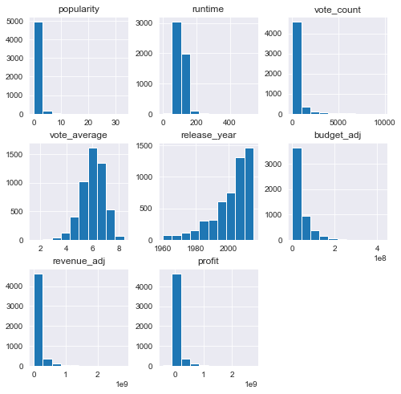

```python
#now we its time to see histogram of our data that would help us get familiar with the data
nz_df.hist(figsize=(8,8));
```

```python
# now we get 2 masks for low budget and high budget to see assusiated
med = nz_df.budget_adj.median()
high_bud = nz_df.query('budget_adj >= {}'.format(med))
high_bud.describe()
```

|  | popularity | runtime | vote_count | vote_average | release_year | budget_adj | revenue_adj | profit |
| --- | --- | --- | --- | --- | --- | --- | --- | --- |
| count | 2583.000000 | 2583.000000 | 2583.000000 | 2583.000000 | 2583.000000 | 2.583000e+03 | 2.583000e+03 | 2.583000e+03 |
| mean | 1.368954 | 113.820751 | 651.867596 | 6.125513 | 2000.809911 | 6.473347e+07 | 1.761881e+08 | 1.114547e+08 |
| std | 1.670397 | 24.154422 | 1007.926558 | 0.789505 | 10.753517 | 4.392039e+07 | 2.475760e+08 | 2.284526e+08 |
| min | 0.010335 | 28.000000 | 10.000000 | 2.200000 | 1960.000000 | 2.274082e+07 | 0.000000e+00 | -4.139124e+08 |
| 25% | 0.537006 | 99.000000 | 90.000000 | 5.600000 | 1996.000000 | 3.342448e+07 | 2.820089e+07 | -1.513136e+07 |
| 50% | 0.937873 | 110.000000 | 273.000000 | 6.100000 | 2003.000000 | 5.008384e+07 | 9.291137e+07 | 4.091809e+07 |
| 75% | 1.610946 | 124.000000 | 742.000000 | 6.600000 | 2009.000000 | 8.102293e+07 | 2.181747e+08 | 1.437787e+08 |
| max | 32.985763 | 540.000000 | 9767.000000 | 8.400000 | 2015.000000 | 4.250000e+08 | 2.827124e+09 | 2.750137e+09 |

```python
# we do the same for low budget
low_bud = nz_df.query('budget_adj < {}'.format(med))
low_bud.describe()
```

|  | popularity | runtime | vote_count | vote_average | release_year | budget_adj | revenue_adj | profit |
| --- | --- | --- | --- | --- | --- | --- | --- | --- |
| count | 2581.000000 | 2581.000000 | 2581.000000 | 2581.00000 | 2581.000000 | 2.581000e+03 | 2.581000e+03 | 2.581000e+03 |
| mean | 0.617122 | 100.377373 | 166.002712 | 5.93952 | 2001.689655 | 9.089755e+06 | 2.833870e+07 | 1.924895e+07 |
| std | 0.680318 | 19.118261 | 331.185493 | 0.95935 | 12.694417 | 6.692630e+06 | 6.774077e+07 | 6.641797e+07 |
| min | 0.001117 | 0.000000 | 10.000000 | 1.50000 | 1960.000000 | 9.210911e-01 | 0.000000e+00 | -2.271505e+07 |
| 25% | 0.259356 | 90.000000 | 21.000000 | 5.30000 | 1995.000000 | 3.038360e+06 | 0.000000e+00 | -6.429194e+06 |
| 50% | 0.434506 | 97.000000 | 52.000000 | 6.00000 | 2006.000000 | 8.108664e+06 | 1.529238e+06 | -8.750365e+05 |
| 75% | 0.743063 | 108.000000 | 163.000000 | 6.60000 | 2011.000000 | 1.441690e+07 | 2.911947e+07 | 1.700316e+07 |
| max | 11.422751 | 338.000000 | 5343.000000 | 8.40000 | 2015.000000 | 2.273036e+07 | 8.530813e+08 | 8.404891e+08 |

```python
low_bud.profit.mean(), high_bud.profit.mean()
```

```
(19248949.049676765, 111454673.91562122)
```

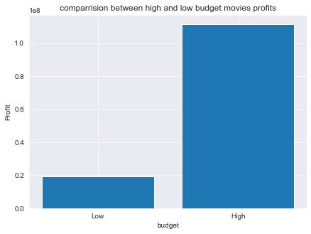

```python
x = [1,2]
y = [low_bud.profit.mean(),high_bud.profit.mean()]
plt.subplots(figsize=(7,5))
plt.bar(x,y,tick_label=['Low','High']);
plt.title('comparrision between high and low budget movies profits')
plt.xlabel('budget');
plt.ylabel('Profit');
```

this visualisation gives us the answer to our first question that higher budget movies tend to gain more profits

we can also do the same with scatter plots to show the corelation between budget and profit

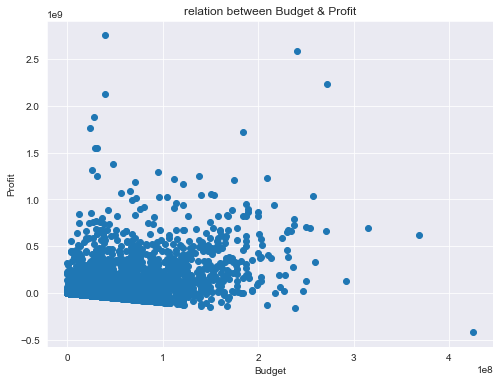

```python
# exploring relation between Budget & Profit
plt.subplots(figsize=(8,6))
plt.scatter(nz_df.budget_adj,nz_df.profit);
plt.title('relation between Budget & Profit')
plt.xlabel('Budget');
plt.ylabel('Profit');
```

now we can clearly see that this is posetively corelated

let's explore more relations using scatter plots

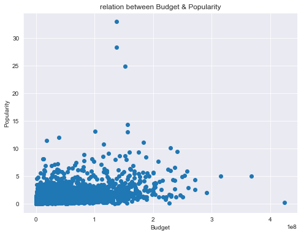

```python
# exploring relation between Budget & Popularity
plt.subplots(figsize=(8,6))
plt.scatter(nz_df.budget_adj,nz_df.popularity);
plt.title('relation between Budget & Popularity')
plt.xlabel('Budget');
plt.ylabel('Popularity');
```

it appers that budget has a insignificant effect on popularity

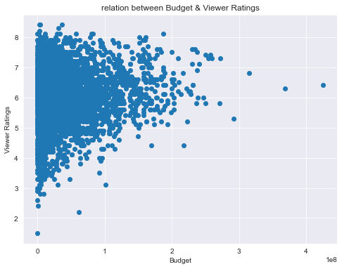

```python
# exploring relation between Budget & Viewer Ratings
plt.subplots(figsize=(8,6))
plt.scatter(nz_df.budget_adj,nz_df.vote_average);
plt.title('relation between Budget & Viewer Ratings')
plt.xlabel('Budget');
plt.ylabel('Viewer Ratings');
```

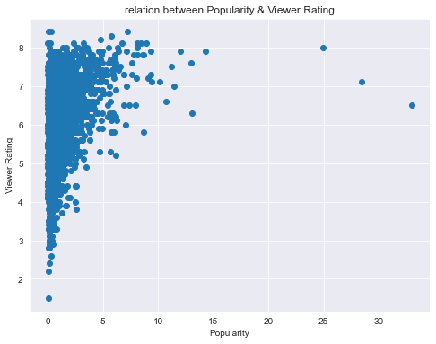

```python
# exploring relation between Popularity & Viewer Rating
plt.subplots(figsize=(8,6))
plt.scatter(nz_df.popularity,nz_df.vote_average);
plt.title('relation between Popularity & Viewer Rating')
plt.xlabel('Popularity');
plt.ylabel('Viewer Rating');
```

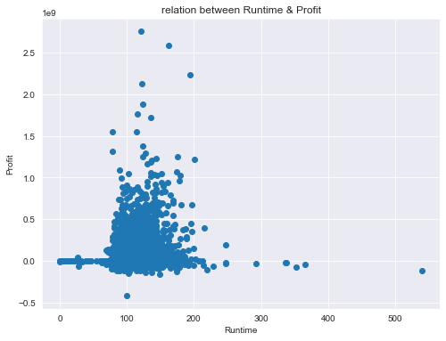

```python
# eventually we are exploring relation between Runtime & Profit
plt.subplots(figsize=(8,6))
plt.scatter(nz_df.runtime,nz_df.profit);
plt.title('relation between Runtime & Profit')
plt.xlabel('Runtime');
plt.ylabel('Profit');
```

we notice that movies with runtime between 100 and 150 are returns higher profits peaking at 120

### Research Question 2: What kinds of properties are associated with movies that have high Profits?

```python
# first we should refernce high profit movies by making a mask of movies that is higher than median
med = nz_df.profit.median()
high_prf = nz_df.query('profit >= {}'.format(med)) # high_prf = high profit
high_prf.describe()
```

|  | popularity | runtime | vote_count | vote_average | release_year | budget_adj | revenue_adj | profit |
| --- | --- | --- | --- | --- | --- | --- | --- | --- |
| count | 2582.000000 | 2582.000000 | 2582.000000 | 2582.000000 | 2582.000000 | 2.582000e+03 | 2.582000e+03 | 2.582000e+03 |
| mean | 1.476575 | 110.898141 | 717.802866 | 6.310767 | 2000.364833 | 4.999868e+07 | 1.955713e+08 | 1.455726e+08 |
| std | 1.703762 | 20.230656 | 1013.270425 | 0.761506 | 12.136578 | 4.807682e+07 | 2.430473e+08 | 2.180701e+08 |
| min | 0.001117 | 26.000000 | 10.000000 | 3.400000 | 1960.000000 | 2.248029e+02 | 4.057946e+06 | 3.392308e+06 |
| 25% | 0.600532 | 96.000000 | 135.500000 | 5.800000 | 1994.000000 | 1.620557e+07 | 5.512301e+07 | 2.692624e+07 |
| 50% | 1.042111 | 107.000000 | 347.500000 | 6.300000 | 2004.000000 | 3.391178e+07 | 1.118725e+08 | 6.887678e+07 |
| 75% | 1.751903 | 121.000000 | 834.000000 | 6.900000 | 2010.000000 | 6.925675e+07 | 2.347144e+08 | 1.664220e+08 |
| max | 32.985763 | 248.000000 | 9767.000000 | 8.400000 | 2015.000000 | 3.683713e+08 | 2.827124e+09 | 2.750137e+09 |

those statistics gives us a great insight of our data

now we visualize the properties associated with high profit to further illustrate the relation

we have already visualized plots of budget and runtime so we wont be including them

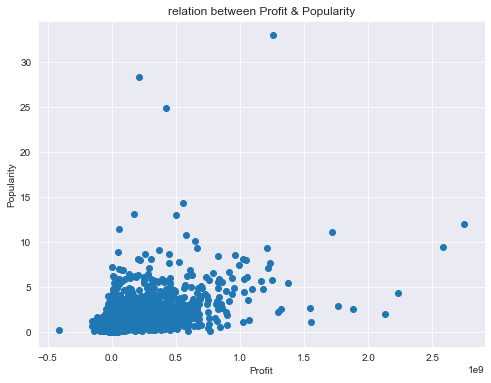

```python
# eventually we are exploring relation between Profit & Popularity
plt.subplots(figsize=(8,6))
plt.scatter(nz_df.profit,nz_df.popularity);
plt.title('relation between Profit & Popularity')
plt.xlabel('Profit');
plt.ylabel('Popularity');
```

looking at this plot it appears profit are positively corelated with popularity

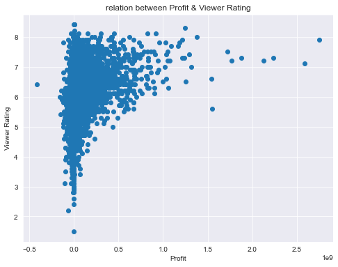

```python
# eventually we are exploring relation between Profit & Viewer Rating
plt.subplots(figsize=(8,6))
plt.scatter(nz_df.profit,nz_df.vote_average);
plt.title('relation between Profit & Viewer Rating')
plt.xlabel('Profit');
plt.ylabel('Viewer Rating');
```

as we can see both have positive corelation but Viewer Rating seem to have a greater effect over profits

### Research Question 3: Which year has the most popular movies?

```python
# we group the data by year then check for the most popular by getting the mean popularity of each year
most_pop_year = nz_df.groupby('release_year')['popularity'].mean()
most_pop_year.idxmax()
```

```
2015
```

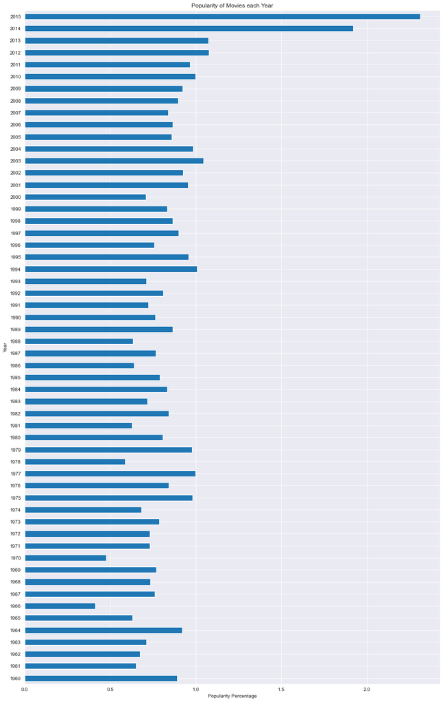

```python
# display our answer with bar plot
most_pop_year.plot(kind='barh',figsize=(15,25));
plt.title('Popularity of Movies each Year')
plt.xlabel('Popularity Percentage');
plt.ylabel('Year');
```

it appears that the most popular year was 2015

```python
# we group the data by genres then check for the most popular by getting the mean popularity of each genre
most_pop_gen = nz_df.groupby('genres')['popularity'].mean()
most_pop_gen.idxmax()
```

```
'Adventure|Science Fiction|Thriller'
```

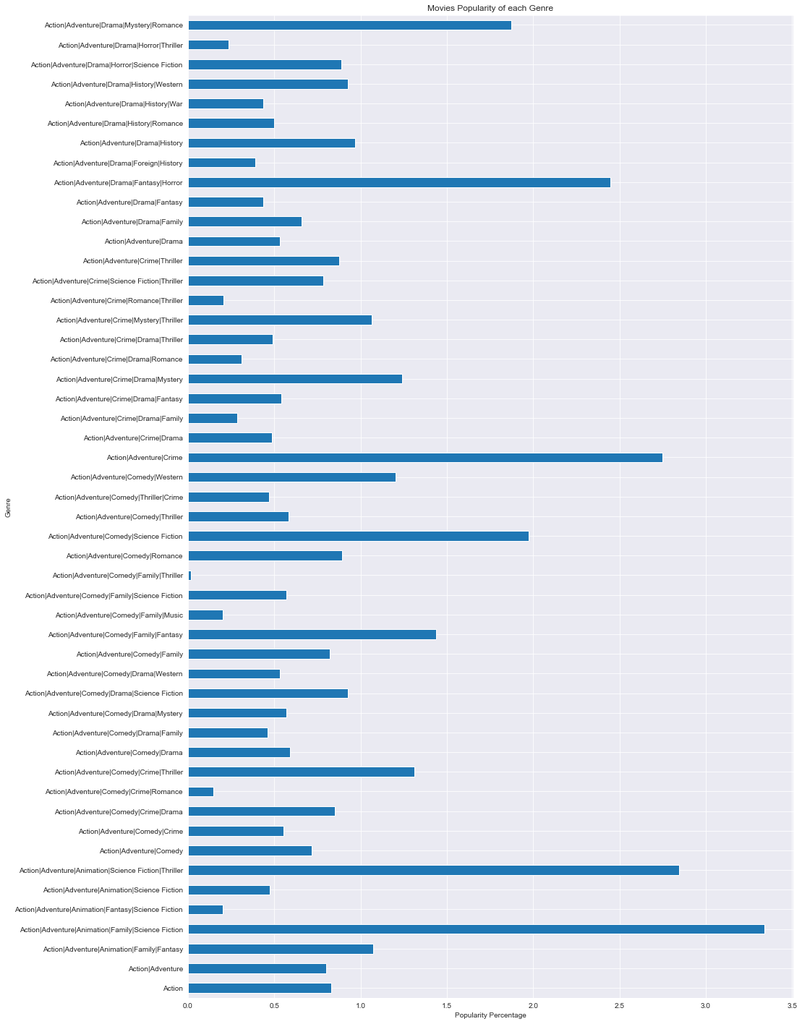

```python
# display our answer with bar plot
most_pop_gen.head(50).plot(kind='barh',figsize=(15,25));
plt.title('Movies Popularity of each Genre')
plt.xlabel('Popularity Percentage');
plt.ylabel('Genre');
```

it appears that the most popular genre is 'Adventure|Science Fiction|Thriller'

as the plot has too many rows we only displayed first 50 just to illustrate the idea

we could also do the same process again to determine which genres has higher profits

```python
# we group the data by genres then check for the most popular by getting the mean profit of each year
most_pop_gen = nz_df.groupby('genres')['profit'].mean()
most_pop_gen.idxmax()
```

```
'Horror|Thriller|Adventure'
```

[figure not shown]

```python
# display our answer with bar plot
most_pop_gen.head(50).plot(kind='barh',figsize=(15,25));
plt.title('Movies Profits of each Genre')
plt.xlabel('Profit');
plt.ylabel('Genre');
```

it appears that the most profiatble genre is 'Horror|Thriller|Adventure'

### Research Question 5: Who is the best director of high quality movies?

> this will be determined depending on the Viewer Rating of each movie

```python
# first we should refernce high rating movies by making a mask of movies that is higher than median
med = nz_df.vote_average.median()
high_rt = nz_df.query('vote_average >= {}'.format(med)) # high_rt = high rating
high_rt.describe()
```

|  | popularity | runtime | vote_count | vote_average | release_year | budget_adj | revenue_adj | profit |
| --- | --- | --- | --- | --- | --- | --- | --- | --- |
| count | 2678.000000 | 2678.000000 | 2678.000000 | 2678.000000 | 2678.000000 | 2.678000e+03 | 2.678000e+03 | 2.678000e+03 |
| mean | 1.285163 | 113.122479 | 612.929798 | 6.703547 | 1999.576176 | 3.979151e+07 | 1.432422e+08 | 1.034507e+08 |
| std | 1.692603 | 26.446610 | 1006.322543 | 0.463391 | 12.937278 | 4.492378e+07 | 2.437903e+08 | 2.193308e+08 |
| min | 0.001117 | 4.000000 | 10.000000 | 6.100000 | 1960.000000 | 1.012787e+00 | 0.000000e+00 | -4.139124e+08 |
| 25% | 0.429179 | 98.000000 | 63.000000 | 6.300000 | 1993.000000 | 9.720226e+06 | 4.492432e+06 | -3.521000e+06 |
| 50% | 0.805533 | 110.000000 | 216.000000 | 6.600000 | 2003.000000 | 2.497402e+07 | 5.111130e+07 | 2.274050e+07 |
| 75% | 1.502474 | 124.000000 | 695.000000 | 7.000000 | 2010.000000 | 5.158835e+07 | 1.677740e+08 | 1.164402e+08 |
| max | 32.985763 | 540.000000 | 9767.000000 | 8.400000 | 2015.000000 | 4.250000e+08 | 2.827124e+09 | 2.750137e+09 |

```python
# we group the data by director then check for the best by getting the mean movie rating of each director
best_dir = high_rt.groupby('director')['vote_average'].mean()
best_dir.idxmax()
```

```
'Jorge RamÃ\xadrez SuÃ¡rez'
```

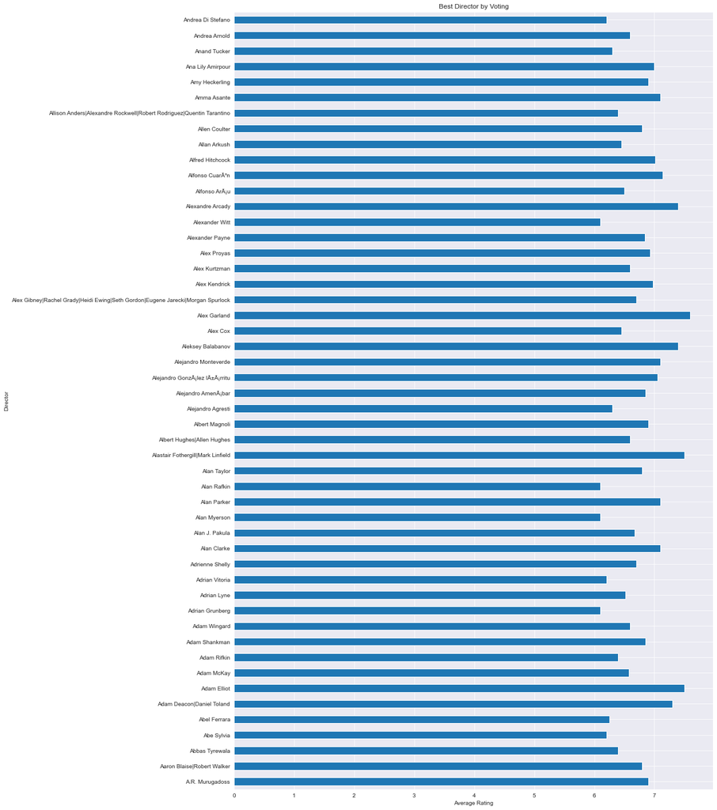

```python
# display our answer with bar plot
best_dir.head(50).plot(kind='barh',figsize=(15,25));
plt.title('Best Director by Voting')
plt.xlabel('Average Rating');
plt.ylabel('Director');
```

it appears that the best director is 'Jorge RamÃ\xadrez SuÃ¡rez'

```python
# we group the data by director then check for the most popular by getting the mean profits of each director
most_prf_dir = nz_df.groupby('director')['profit'].mean()
most_prf_dir.idxmax()
```

```
'Clyde Geronimi|Hamilton Luske|Wolfgang Reitherman'
```

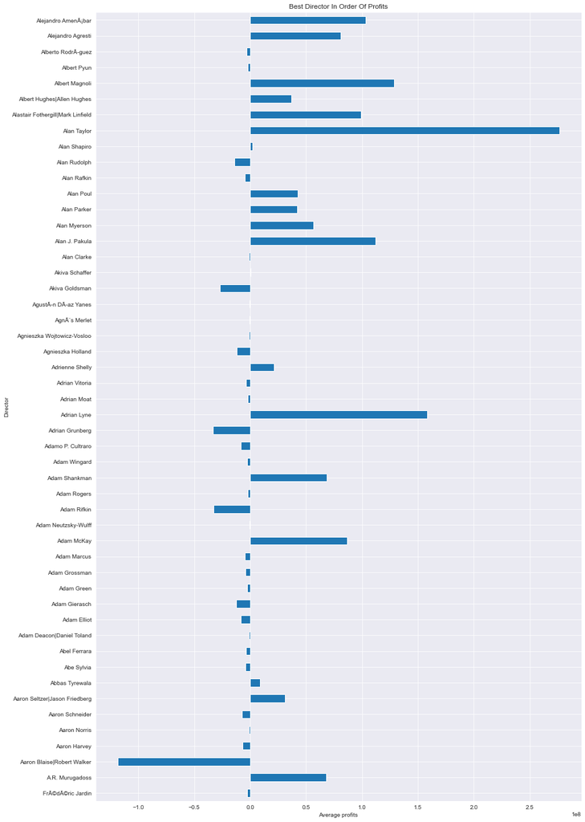

```python
# display our answer with bar plot
most_prf_dir.head(50).plot(kind='barh',figsize=(15,25));
plt.title('Best Director in order of profits'.title())
plt.xlabel('Average profits');
plt.ylabel('Director');
```

## Conclusions

### Finally, we can answer the questions we posed earlier

> **Q1: Does higher budget movies means higher profits?**  
> *Answer:* we can clearly see that this is posetively corelated which means that higher budget mostly leads to higher profits

> **Q2: What kinds of properties are associated with movies that have high Profits?**  
> *Answer:*  
> average budget for high profit movies is **4.999868e+07**  
> average run time for high profit movies is **111**  
> Best director for high profit movies is **Clyde Geronimi | Hamilton Luske | Wolfgang Reitherman**

> **Q3: Which year has the most popular movies?**  
> *Answer:* **2015** is the has popular movies

> **Q4: Which genres are most popular?**  
> *Answer:* **Adventure|Science Fiction|Thriller**is the most popular genre overall

> **Q5: Who is the best director of high rated movies?**  
> *Answer:* **Jorge RamÃ\xadrez SuÃ¡rez**is the best director of high rated movies

### **Limitations:**

- We dropped columns that didn't relate to our questions eg.(cast, production_companey) which could be helpfull to answer other questions
- The dataset has missing values and zeros for the revenue ,budget and profit
- The charachteristics of the movie can not guarantee the success or the faliure of it